# 6강 재현성 있는 문서작성

기본 YAML

Author

최요한

Published

June 26, 2026

## 0.1 Quarto

## 0.2 Running Code

```
[1] 4
```

# 1 Render와 화면 설정

## 1.1 Render

> Quarto 문서를 html 파일로 생성하기

> 단축키: ctrl + shift + k

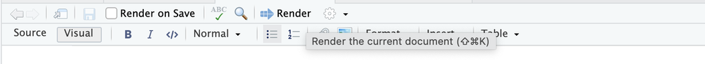

## 1.2 View 설정

> Render 옆 ‘톱니바퀴’ 버튼

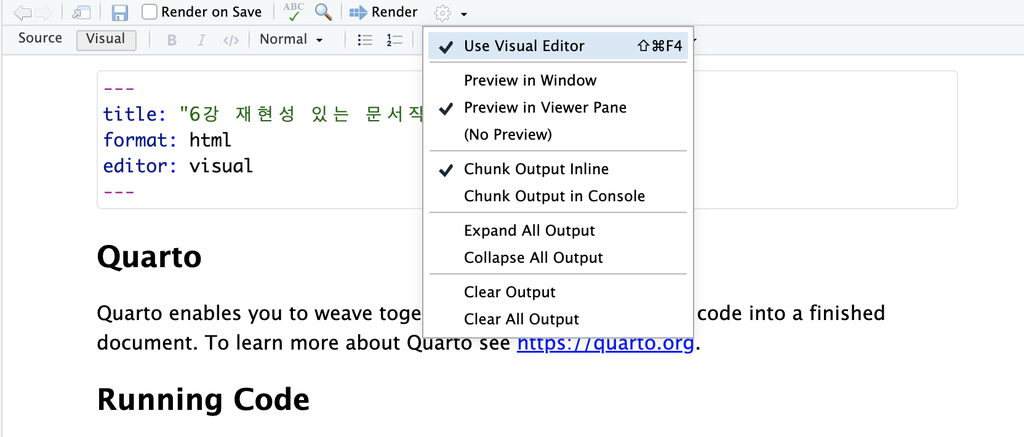

도구상자 > 톱니바퀴

### 1.2.1 설명

- Use Visual Editor (추천)
  - 체크하면 워드(Word)나 노션(Notion)처럼 ’비주얼 에디터’를 사용하고 체크를 해제하면 마크다운(Markdown) 코드가 그대로 노출되는 ’소스 에디터’를 사용합니다.
- Preview in Window (새 창에서 미리보기)
- Preview in Viewer Pane (Viewer 창에서 미리보기, 추천)
- Chunk Output Inline (코드 청크 아래에 출력)
  - 현재 체크되어 있는 옵션입니다. R 코드 블록(청크)을 실행했을 때, 그 결과(표, 그래프, 텍스트 등)를 소스 코드 바로 아래(문서 내부)에 끼워 넣어서 보여줍니다.
- Chunk Output in Console (콘솔 창에 출력, 추천)
  - 코드 블록을 실행했을 때, 결과물을 문서 내부가 아닌 RStudio 하단의 **Console(콘솔) 창**이나 **Plots 창**에 분리하여 출력합니다. 전통적인 R 스크립트 실행 방식과 같습니다.

# 2 다양한 요소 추가

## 2.1 Insert

> 설정보기

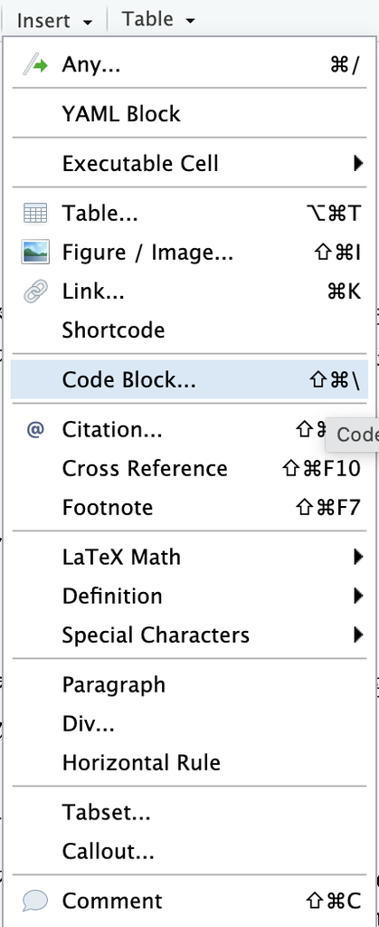

추가하기